```python
from IPython.display import Image
import numpy as np
import matplotlib.pyplot as plt
import seaborn as sns; sns.set(style='white')
%matplotlib inline
from sklearn import decomposition
from sklearn import datasets
from mpl_toolkits.mplot3d import Axes3D

import warnings
warnings.simplefilter("ignore")
```

# Тема НИР:

"Применение алгоритмов машинного обучения к задаче распознавания радиолокационных объектов на основе измерений поляризационной матрицы рассеяния"

![radiolocation](radio.jpg "asdad")

# Суть работы:

Одним из методов получения информации о характеристиках наблюдаемой цели является поляризационная матрица рассеяния(ПМР):

$S = \begin{pmatrix} S_{vv} & S_{vh} \\ S_{hv} & S_{hh} \end{pmatrix}$, где

$S_{vv}$ - отклик цели при облучении ее сигналом с линейной вертикальной поляризацией и приеме на линейной вертикальной поляризации;  
$S_{vh}$ - отклик цели при облучении ее сигналом с линейной вертикальной поляризацией и приеме на линейной горизонтальной поляризации;  
$S_{hv}$ - отклик цели при облучении ее сигналом с линейной горизонтальной поляризацией и приеме на линейной вертикальной поляризации;  
$S_{hh}$ - отклик цели при облучении ее сигналом с линейной горизонтальной поляризацией и приеме на линейной горизонтальной поляризации.

$S_{vv}, S_{vh}, S_{hv}, S_{hh} \in \mathbf{С}$

$S_{vh} = -S_{hv}$

Следовательно, наблюдаемая цель в определенном положении в пространстве, заданного тремя углами Эйлера $(\alpha, \beta, \gamma)$, описывается вектором из 6 действительных чисел:

$\overrightarrow{x} = \begin{bmatrix} Re(S_{vv}) & Im(S_{vv}) & Re(S_{vh}) & Im(S_{vh}) & Re(S_{hh}) & Im(S_{hh})) \end{bmatrix}^{T}$

Задача распознавания представляет из себя типичную задачу классфикации: необходимо построить функцию $f(x)$, которая ставит в соответствие вектору признаков один из заданных типов радиолокационного объекта

На данном этапе работы мы пока не пришли к решению о том, будет ли это все-таки задача классификации, кластеризации или же совокупность этих задач. Это станет понятно, когда мы начнем работать с модельными данными.

# Проделанная работа и результаты

1. Изучены работы прошлых лет по данной тематике(Волкова, Олюнин)
1. Изучены математические основы алгоритмов: SVN, k-means, PCA, SNE, t-SNE

# Dimensionality Reduction

### Principal Component Analysis (PCA)

PCA - линейный метод снижения размерности. Мы пытаемся приблизить наши $n$ - мерные данные $d$ - мерным линейным подпространством($d < n$).

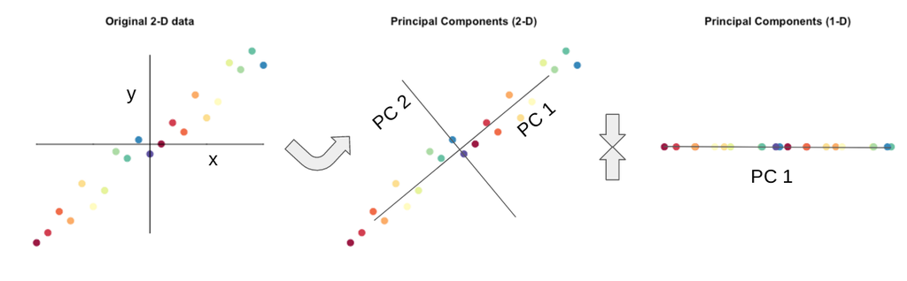

```python
Image("pca.jpg")
```

**Рис.1 Иллюстрация работы PCA**

**Суть метода** - сохранить как можно больше информации о выборке. Делается это следующим образом:

```
1. Находим направление, сумма квадратов длин проекций исходных векторов на которое максимальна.
2. Из исходных векторов вычитаем проекции на найденное направление.
3. На полученных данных ищем следующую компоненту
```

Математически задача сводится к оптимизационной задаче:

$${\mathbf {w}}={\underset {\Vert {\mathbf {w}}\Vert =1}{\operatorname {\arg \,max}}}\,\left\{\sum _{i}\left({\mathbf {x}}_{{(i)}}\cdot {\mathbf {w}}\right)^{2}\right\}$$

### t-SNE

Stochastic Neighbor Embedding (SNE) - вероятностный метод снижения размерности.

Суть базового метода заключается в следующем:

- Определяется "похожесть" двух объектов $x_j$ и $x_i$ как условная вероятность $p_{j\vert i}$. Делается предположение, что вероятность того, что ты окажешься соседом $x_i$ пропорциональна плотности нормального распределения с центром в $x_i$.

$$p_{j\vert i} = \frac{\exp\big(\frac{ - \vert x_i - x_j \vert^2}{\sigma_i^2}\big)}{\sum_{k \neq i} \exp\big(\frac{ - \vert x_i - x_k \vert^2}{\sigma_i^2}\big)}$$

- Мы хотим найти низкоразмерное представление $y_i$ вектора $x_i$. Теперь мы говорим, что в низкоразмерность тоже есть эта похожесть $q_{j\vert i}$, которую мы можем записать как

$$q_{j\vert i} = \frac{\exp\big(- \vert y_i - y_j \vert^2\big)}{\sum_{k \neq i} \exp\big(- \vert y_i - y_k \vert^2\big)}$$

- А теперь мы хотим, чтобы эти распределения были как можно ближе друг к другу. Как померить расстояния между распределениями? Есть такое расстояние Кульбака - Лейблера, которое считается следующим образом: $${\displaystyle D_{\mathrm {KL} }(P\|Q)=\int _{X}\,p(x)\log {\frac {p(x)}{q(x)}}\,{\rm {d}}x}$$

В нашем случае будет считаться его дискретный вариант

$${\displaystyle \sum_{i} D_{KL}(P_i||Q_i)=\sum \limits _{i} \sum \limits _{j}p_{j\vert i}\log {\frac {p_{j\vert i}}{q_{j\vert i}}}}.$$

А дальше идут навороты:

- На самом деле мы можем оптимизировать не для условных вероятностей, а для совместных, причём пологать, что $p_{ji} = p_{ij}$ и $q_{ji} = q_{ij}$. $q_{ij}$ оставляют как условное, а $p_{ij} = \frac{p_{j\vert i} + p_{i\vert j}}{2n}$. Вот это симметричный вариант.
- А теперь говорят, что в низкоразмерном брать нормальное распределение не очень, давайте возьмём распределение Стьюдента. $${\displaystyle q_{ij}={\frac {(1+\lVert \mathbf {y} _{i}-\mathbf {y} _{j}\rVert ^{2})^{-1}}{\sum _{k\neq i}(1+\lVert \mathbf {y} _{i}-\mathbf {y} _{k}\rVert ^{2})^{-1}}}}$$

### Iris dataset visualization

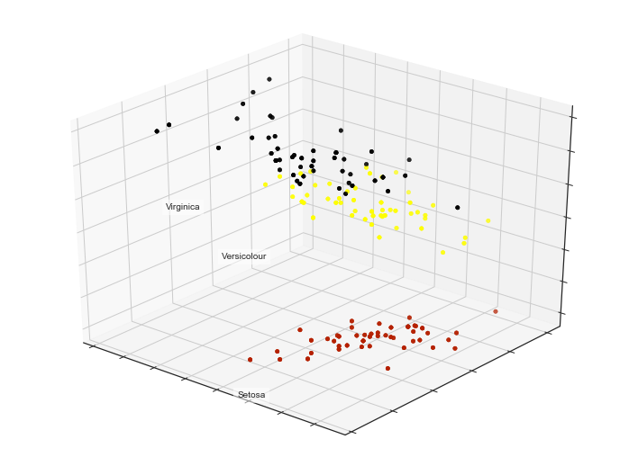

```python
iris = datasets.load_iris()
X = iris.data
y = iris.target

fig = plt.figure(1, figsize=(10,7))
plt.clf()
ax = Axes3D(fig, rect=[0, 0, .95, 1], elev=30, azim=130)

plt.cla()

for name, label in [('Setosa', 0), ('Versicolour', 1), ('Virginica', 2)]:
    ax.text3D(X[y == label, 0].mean(),
              X[y == label, 1].mean() + 1.5,
              X[y == label, 2].mean(), name,
              horizontalalignment='center',
              bbox=dict(alpha=.5, edgecolor='w', facecolor='w'))
    y_clr = np.choose(y, [1, 2, 0]).astype(np.float)
    ax.scatter(X[:, 0], X[:, 1], X[:, 2], c=y_clr, cmap=plt.cm.get_cmap("gnuplot"))

    ax.w_xaxis.set_ticklabels([])
    ax.w_yaxis.set_ticklabels([])
    ax.w_zaxis.set_ticklabels([])
```

**Рис.2 Визуалиция Iris Dataset по 3-м первым компонентам**

### Используем PCA

```python
from sklearn.tree import DecisionTreeClassifier
from sklearn.model_selection import train_test_split
from sklearn.metrics import accuracy_score, roc_auc_score

X_train, X_test, y_train, y_test = train_test_split(X, y, test_size=.3, stratify=y, random_state=42)

clf = DecisionTreeClassifier(max_depth=2, random_state=42)
clf.fit(X_train, y_train)
preds = clf.predict_proba(X_test)
print('Accuracy: {:.5f}'.format(accuracy_score(y_test, preds.argmax(axis=1))))
```

```
Accuracy: 0.88889
```

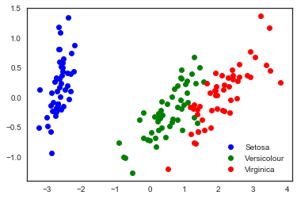

```python
pca = decomposition.PCA(n_components=2)

X_centred = X - X.mean(axis=0)
pca.fit(X_centred)
X_pca = pca.transform(X_centred)

plt.plot(X_pca[y == 0, 0], X_pca[y == 0, 1], 'bo', label='Setosa')
plt.plot(X_pca[y == 1, 0], X_pca[y == 1, 1], 'go', label='Versicolour')
plt.plot(X_pca[y == 2, 0], X_pca[y == 2, 1], 'ro', label='Virginica')
plt.legend(loc=0);
```

**Рис.3 Наши точки в новом пространстве**

Обучаем после снижения размерности

```python
X_train, X_test, y_train, y_test = train_test_split(X_pca, y, test_size=.3, stratify=y, random_state=42)
clf = DecisionTreeClassifier(max_depth=2, random_state=42)
clf.fit(X_train, y_train)
# Предсказываем. Индекс столбца - целевой класс
preds = clf.predict_proba(X_test)

print('Accuracy: {:.5f}'.format(accuracy_score(y_test, preds.argmax(axis=1))))
```

```
Accuracy: 0.91111
```